# Sevilla Humanidades Digitales II De Benito

Carlota de Benito Moreno

5/22/2022

# Humanidades Digitales II

## Introducción a R

### Carlota de Benito Moreno (UZH)

## Instalar librerías y cargarlas

R es un lenguaje de programación de código abierto, lo que significa que está siendo constantemente enriquecido por medio de librerías (o paquetes) que amables programadores preparan para hacernos la vida más fácil.

Una de las librerías más recomendables es el tidyverse, que en realidad es un universo de librerías que siguen la misma sintaxis y la misma filosofía: se parte de una base de datos —es decir, una tabla— ordenada (tidy), que sigue dos principios fundamentales:

1. Cada columna es una (y solo una) variable.
2. Cada fila es una (y solo una) observación.

Además de poder encontrar mucha más información en Google, en su día preparé un vídeo al respecto: https://www.youtube.com/watch?v=nD927zeUPqc

¡Pero dejémenos de rodeos! Como las librerías son “extra”, lo primero que hay que hacer es descargarlas. Esto se hace solo una vez (salvo que actualices R, que tendrás que volver a instalarlas). Ejecuta el código que aparece a continuación, sin la almohadilla (#).

```r
#install.packages("tidyverse")
```

Todo lo que va detrás de una almohadilla es invisible para R: no lo lee. Por lo tanto, la almohadilla sirve para hacer comentarios, pero también para “ocultar” código que no queremos ejecutar cada vez.

Instalar una librería no es suficiente, eso sirve para tenerla disponible en el ordenador. Pero cada vez que abramos una nueva sesión de R tenemos que cargar las librerías que necesitemos. Adelante, ejecuta el código que sigue:

```r
library(tidyverse)
```

## Seleccionar el directorio de trabajo

Como desde R podemos leer y escribir archivos, conviene que R sepa de qué carpeta leer y en qué carpeta escribir archivos. Eso se llama directorio de trabajo (working directory) y, desde RStudio, lo más fácil es hacerlo desde la pestaña Files que tienes en la ventana inferior derecha. Navega hasta la carpeta que vas a usar para este curso y, una vez en ella, pincha en “More” y dale a "Set as working directory). Verás que en la consola (ventana inferior izquierda) ha aparecido una línea de código encabezada por la función `setwd()`. Mi consejo es que la copies en tu script: así te ahorras tener que navegar cada vez.

¡Ser vaga es una cualidad muy apreciada en la programación eficiente!

## Leer un archivo .txt y cambiar su codificación

Vamos a trabajar con La lista de 5000 palabras más frecuentes del CREA, que la RAE pone a nuestra disposición. Es un archivo de texto (.txt), aunque está estructurado como una tabla separada por tabuladores (.tsv). Primero vamos a leerlo como un archivo de texto, para jugar un poco con él.

Lo primero que hacemos es asignarle un nombre (`crea`) a la URL en la que está guardado el archivo.

```r
crea <- "http://corpus.rae.es/frec/5000_formas.TXT"
crea
```

```
## [1] "http://corpus.rae.es/frec/5000_formas.TXT"
```

Como veis, no hemos leído todavía el texto, solo la URL. Leamos el texto:

```r
crea_txt <- read_lines(crea) #lo leemos y lo llamamos `crea_txt`
crea_txt
```

Al examinarlo vemos que la codificación del texto no está bien: salen algunos símbolos no desados. Eso se debe a que la función read_lines() asume por defecto que el texto leído estará codificado como UTF-8 (el estándar unicode más usado en la actualidad), pero la RAE codificó el texto en latin1, que ya está anticuado. Pero R nos permite cambiarlo. Vamos a ejectuar varios pasos; te los explico en los comentarios.

```r
Encoding(crea_txt) #Aquí comprobamos la codificación. Cuando no hay símbolos "raros" (con tildes, etc.), R nos dice que la codificación es "unknown": eso es porque podría ser cualquiera, es compartida entre latin1 y UTF-8. Cuando sí los hay, nos dice que es UTF-8: sabemos que no puede ser así, porque no podemos ver los símbolos correspondientes.
Encoding(crea_txt) <- "latin1" #le decimos que la codificación del texto es latin1
Encoding(crea_txt) #comprobamos que ha cambiado la codificación
crea_txt #y que ahora sí vemos bien los símbolos
crea_txt <- enc2utf8(crea_txt) #Como UTF-8 es el estándar más usado, ahora que lo vemos bien, vamos a convertirlo de latin1 a UTF-8, así no tendremos problemas en el futuro.
Encoding(crea_txt) #Volvemos a comprobar la codificación
crea_txt #y que se ven correctamente los textos
```

Aunque lo hemos leído como si fuera un texto corrido, línea a línea, en realidad tenemos una tabla. Lo podríamos convertir nosotros en una tabla desde el formato actual, pero es más fácil leerlo directamente como tal y luego hacer los cambios necesarios. Veamos

```r
#El resultado lo vamos a llamar `crea_table`
crea_table <- read_delim(crea, #queremos leer la URL guardad como `crea`
                         delim = "\t", #le explicamos que las columnas están delimitadas por tabuladores ("\t")
                         col_names = c("order", "word", "abs_freq", "rel_freq"), #damos nombres a las columnas, porque la RAE no lo ha hecho muy ordenadamente
                         trim_ws = T) # le decimos que elimine los espacios en blanco que aparecen antes o detrás de cada celda, que sobran
crea_table #comprobamos el resultado: por defecto vemos las 10 primera filas
head(crea_table, n = 15) #con `head()` podemos ver las primeras filas (cuantas queramos, solo hay que especificarlo en el argumento n)
tail(crea_table) #con `tail()` lo mismo, pero las últimas filas
```

A la tabla le quedan todavía algunos detalles para estar bien del todo… Nos sobran la primera y la última fila, para empezar. Además, necesitamos que R sepa que algunas filas contienen números: las ha codificado todas como texto.

Vamos a encadenar varias funciones, una tras otra, porque queremos hacerle muchas cosas a la tabla. Para eso nos viene muy bien la llamada pipe `%>%`, que nos permite encadenar funciones de forma muy fácil de leer. Cada vez que ve una pipe, R entiende que debe poner todo lo anterior como primer argumento de la función que siga. Veamos. (Guardaremos el resultado en un objeto llamado `crea_table_clean`.)

```r
crea_table_clean <- crea_table %>% #partimos de `crea_table`, primer argumento de la siguiente función
  slice(-c(1, 5002)) %>% #eliminamos la primera fila y la última (que es la 5002). La función `c()` sirve para generar vectores de elementos, en este caso, un conjunto de dos números: las dos filas a eliminar.
  mutate(abs_freq = str_remove_all(abs_freq, ",")) %>% #R no entiende las comas como separadores de miles, así que las eliminamos. Para eso tenemos que modificar nuestra columna `abs_freq` con `mutate()`: la nueva columna eliminará todas las comas de dicha columna
  mutate(order =  as.integer(order), #cambiamos más columnas, para convertirlas en números, con `as.integer()`
         abs_freq =  as.integer(abs_freq),
         rel_freq = as.double(rel_freq)) #o `as.double`, si tienen decimales
crea_table_clean #comprobamos la tabla: el inicio
tail(crea_table_clean) #y el final
```

Cambiar la codificación de texto dentro de la tabla es un poco más complicado: como ahora tenemos columnas, tenemos que aplicar `mutate()` para los cambios. La nomenclatura `nombre_tabla$nombre_columna` es propia del R básico (es decir, no del tidyverse) y sirve para identificar una columna concreta de una tabla.

```r
Encoding(crea_table_clean$word) #comprobamos la codificación de la columna `word`.
Encoding(crea_table_clean$word) <- "latin1" #la cambiamos a `latin1`, que es la que le corresponde en realidad.
crea_table_clean <- crea_table_clean %>% #modificamos crea_table_clean (no damos un nombre nuevo, sino el mismo)
  mutate(word = enc2utf8(word)) #cambiamos la codificación de la columna `word` usando `mutate()`
tail(crea_table_clean) #comprobamos el resultado
Encoding(crea_table_clean$word) #comprobamos la codificación
```

Limpiar la tabla (que es nuestra base de datos) lleva siempre un buen rato. Especialmente si no la hemos generado nosotros: nosotrosp odemos adoptar buenas prácticas para facilitar la tarea luego.

Ahora que la tenemos lista, vamos a investigar un poco algunos sufijos nominales, concretamente -ción/-sión y -miento/-mento. Vamos a crear una nueva tabla que contenga solamente aquellas palabras que acaben en una de estas terminaciones. Después lo escribiremos como un .csv, para que podamos comprobar nuestros datos manualmente.

```r
crea_table_clean %>% #no lo vamos a guardar de ninguna manera, pues lo queremos escribir como un .csv
  mutate(sufijo = str_extract(word, "([cs]ión|mi?ento)$")) %>% #creamos una nueva columna, llamada "sufijo", que extraiga las terminaciones de todas las palabras acabadas en nuestras terminaciones. Para eso estamos usando una expresión regular: "([cs]ión|mi?ento)$"
  filter(!is.na(sufijo)) %>% #eliminamos todas aquellas filas que tengan NA en la columan sufijo (es decir, que estén vacías en esa columna)
  #filter(sufijos == "mento") %>% #hagamos una pequeña prueba, examinando aquellos que acaben en -mento. Luego le pondremos la almohadilla delante, porque no nos interesa quedarnos solo con esos
  #View() #con `View()` podemos ver toda la tabla de una forma más cómoda, pero en el mismo RStudio
  write_delim("crea_sufijos_nominales.csv", delim = "\t") #finalmente, contentos con el resultado, lo escribimos como un .csv delimitado por tabuladores y llamado `crea_sufijos_nominales.csv`. Se guardará en nuestro directorio de trabajo, ya verás ;)
```

Ahora que tenemos un archivo que podemos modificar en algún editor de hojas podemos añadir y alterar cosas a nuestro gusto y luego volver a leerlo, esta vez no desde una URL, sino desde un archivo localizado en nuestro directorio de trabajo. El código es muy similar al de arriba:

```r
crea_sufijos <- read_delim("crea_sufijos_nominales.csv", delim = "\t") #la guardamos como crea_sufijos
```

Vamos a crear algunos gráficos que nos permitan entender mejor nuestros datos. En el tidyverse los gráficos se crean con la librería (ya incluida y cargada) `ggplot2`. Entender al principio su sintaxis es un poco difícil, pero permite hacer unos gráficos maravillosos. Enseguida se acostumbra uno y el resultado merece la pena. `ggplot2` funciona a base de capas (cada una tiene su propia función), que se añaden con un `+`. Siempre se empieza con `ggplot()`, que contendrá dentro la función `aes()`, donde se le dicen las distintas dimensiones del gráfico (los ejes x, y, colores, formas, rellenos…). Luego sigue una función (o varias) con el tipo de gráfico (geometrías, en lenguaje de ggplot2) y, por último, puedes determinar las “etiquetas” (títulos, etc.) y el fondo del gráfico.

Hagamos un gráfico de columnas que indique cuántas palabras presentan cada uno de los cuatro sufijos en las 5000 palabras más frecuentes del CREA:

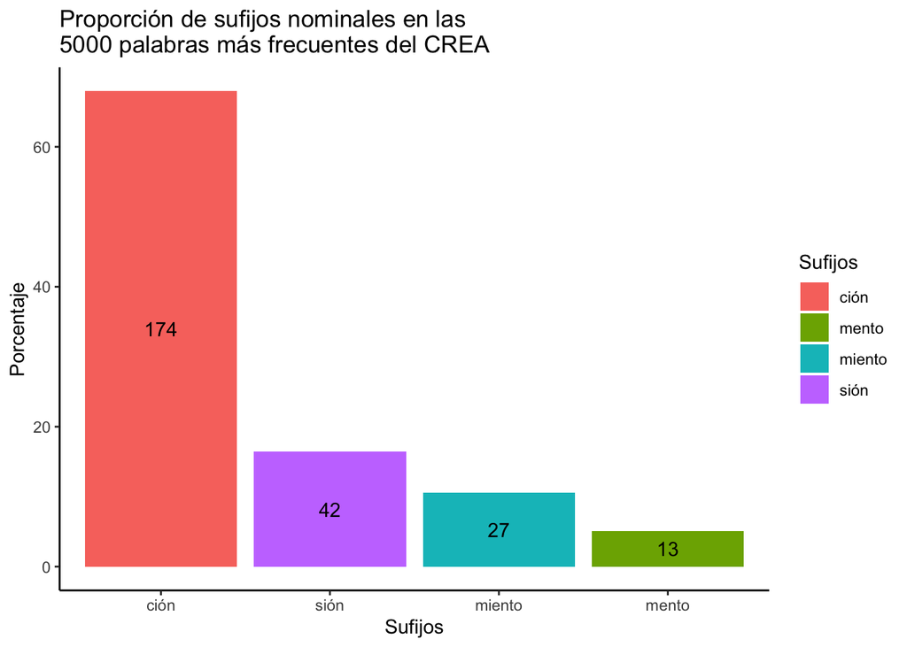

```r
crea_sufijos %>% #lo primero es preparar la tabla (no vamos a guardar el resultado, que será un gráfico, aunque podríamos)
  count(sufijo) %>% #contamos cuantas veces aparece cada sufijo en la columna `sufijo`, es decir, cuántas palabras hay con cada sufijo
  mutate(Porcentaje = n/sum(n)*100) %>% #creamos una nueva columna, con el porcentaje que representa cada sufijo. Es decir, dividimos el valor de `n` por la suma de todos los valores contenidos en `n` y lo multiplicamos por 100.
  ggplot(aes(x = reorder(sufijo, desc(n)), y = Porcentaje, fill = sufijo)) + #empezamos el gráfico, que tendrá varias dimensiones: en el eje x, los sufijos, ordenados en función del valor (descendente) de `n`; en el eje y, el porcentaje; y como color de las columnas, el sufijo (más decorativo)
  geom_col() + #va a ser un gráfico de columnas, así que usamos geom_col()
  geom_text(aes(label = n), position = position_stack(vjust = .5)) + #pero también nos gustaría tener la información de cuántos casos (frecuencia absoluta) de cada sufijo hay: lo hacemos con la geometría geom_text, indicando que la etiqueta que ha de aparecer es el valor de `n` y que debe aparecer en el medio de las columnas
  labs(title="Proporción de sufijos nominales en las \n5000 palabras más frecuentes del CREA",
       x = "Sufijos", fill = "Sufijos") + #añadimos títulos y nombres de los ejes/dimensiones que no nos satisficieran
  theme_classic() #escogemos el tema clásico para el fondo, que no está mal
```

¡Tará! Ahí está nuestro gráfico. Todavía podríamos ponerlo más bonito (por ejemplo, hay muchas posibilidades para escoger colores). Pero, por ahora, vamos a guardarlo. La función `ggsave()` guarda por defecto el último gráfico (aunque, si les damos un nombre a los gráficos también puede guardar otros, basta con que le digamos cuáles).

```r
ggsave("sufijos_nominales.tiff") #¡no te olvides de ponerle una extensión al nombre del archivo! Además hay otros argumentos que se pueden usar para modificar el tamaño del gráfico (scale, width, height…)
```

Quiero enseñarte todavía alguna otra cosa que puede hacer el estupendo ggplot2, así que vamos a hacer un nuevo gráfico, esta vez con las 20 palabras más frecuentes por sufijo de nuestra tabla.

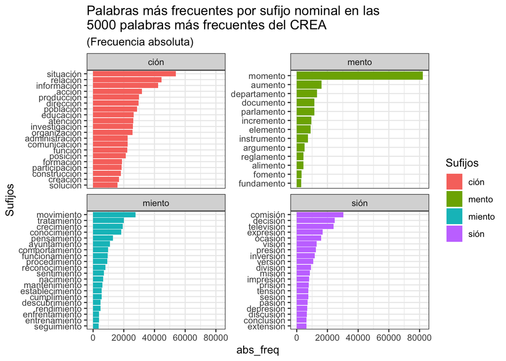

```r
crea_sufijos %>% #otra vez, lo primero es preparar la tabla
  group_by(sufijo) %>% #agrupamos la tabla por sufijos, pues queremos quedarnos con los más frecuentes de cada uno. Esto aplicará las próximas funciones a cada grupo
  slice_head(n = 20) %>% #nos quedamos con los 20 más frecuentes (si no estuvieran ya ordenados, tendríamos que añadir el argumento `order_by` para indicarle qué columnas son las más altas)
  ungroup() %>% #desagrupamos la tabla, que es una medida de higiene que siempre tiene sentido
  ggplot(aes(x = reorder(word, abs_freq), y = abs_freq, fill = sufijo)) + #empezamos el gráfico: nuestras dimensiones son, en el eje x, las palabras, ordenadas por su frecuencia absoluta; en el y, la frecuencia absoluta; como color de las columnas, el sufijo
  geom_col() + #nuestra geometría vuelven a ser las columnas
  labs(title="Palabras más frecuentes por sufijo nominal en las \n5000 palabras más frecuentes del CREA",
       subtitle = "(Frecuencia absoluta)",
       x = "Sufijos", fill = "Sufijos") + #añadimos los títulos que queremos
  theme_bw() + #vamos a probar el tema blanco y negro ahora
  coord_flip() + #ahora vamos a intercambiar los ejes x e y, porque así se leen mejor nuestras palabras
  facet_wrap(~sufijo, scales = "free_y") #y le damos el último toque de gracia: con `facet_wrap()` sacamos un gráfico más pequeño por cada grupo que queramos; en este caso, los sufijos. Además, para no heredar todas las palabras en cada gráfico, "liberamos" la escala del eje y (donde ahora están las palabras)
```

Si no te has quedado impresionado y deseando aprender esta magia negra, yo ya no sé qué decir ;) Guardemos el gráfico, ¿no?

```r
ggsave("palabras_frecuentes_sufijos_nominales.tiff")
```